# Phase 1 — Who Is Leaving? Exploratory Analysis

Zohair Khan

2026-07-07

## Purpose

Before any modeling, answer the HR director’s first question plainly: **who is leaving, and which groups are leaving fastest?** Everything flagged here becomes a candidate driver for the formal hypothesis tests in Phase 2.

## Data integrity

```r
hr <- read_csv("data/hr-attrition.csv", show_col_types = FALSE)

tibble(
  rows = nrow(hr),
  cols = ncol(hr),
  missing_values = sum(is.na(hr)),
  duplicate_employee_ids = sum(duplicated(hr$EmployeeNumber))
)
```

```
## # A tibble: 1 × 4
##    rows  cols missing_values duplicate_employee_ids
##   <int> <int>          <int>                  <int>
## 1  1470    35              0                      0
```

The dataset is complete: no missing values, one row per employee. Three columns carry no information (`EmployeeCount`, `StandardHours`, `Over18` are constant for every row) and `EmployeeNumber` is an ID, so all four are excluded from analysis. `EmployeeNumber` is kept as the join key for the risk-score outputs in Phase 3.

```r
constant_cols <- hr %>% summarise(across(everything(), n_distinct)) %>%
  pivot_longer(everything()) %>% filter(value == 1) %>% pull(name)
constant_cols
```

```
## [1] "EmployeeCount" "Over18"        "StandardHours"
```

```r
hr <- hr %>% select(-all_of(constant_cols))
```

## Overall attrition

```r
overall <- hr %>% count(Attrition) %>% mutate(share = n / sum(n))
overall
```

```
## # A tibble: 2 × 3
##   Attrition     n share
##   <chr>     <int> <dbl>
## 1 No         1233 0.839
## 2 Yes         237 0.161
```

```r
attrition_rate <- overall %>% filter(Attrition == "Yes") %>% pull(share)
```

**16.1% of the workforce left** (237 of 1470 employees). At a flat replacement cost of $15K per leaver — the placeholder parameter this project carries through to the dashboard — that is roughly **$3.6M per year**.

## Which groups are leaving fastest?

A reusable helper: attrition rate by group, with group sizes visible so small-n groups don’t get over-read.

```r
rate_by <- function(df, col) {
  df %>%
    group_by({{ col }}) %>%
    summarise(n = n(), leavers = sum(Attrition == "Yes"),
              attrition_rate = leavers / n, .groups = "drop") %>%
    arrange(desc(attrition_rate))
}

plot_rate <- function(df, col, title) {
  d <- rate_by(df, {{ col }})
  ggplot(d, aes(x = reorder({{ col }}, attrition_rate), y = attrition_rate)) +
    geom_col(fill = "#e15759") +
    geom_hline(yintercept = attrition_rate_overall, linetype = "dashed") +
    geom_text(aes(label = paste0(percent(attrition_rate, 1), " (n=", n, ")")),
              hjust = -0.05, size = 3.2) +
    scale_y_continuous(labels = percent, limits = c(0, .55)) +
    coord_flip() +
    labs(title = title, x = NULL, y = "Attrition rate",
         caption = "Dashed line = company-wide attrition rate")
}
attrition_rate_overall <- attrition_rate
```

### Overtime is the loudest single signal

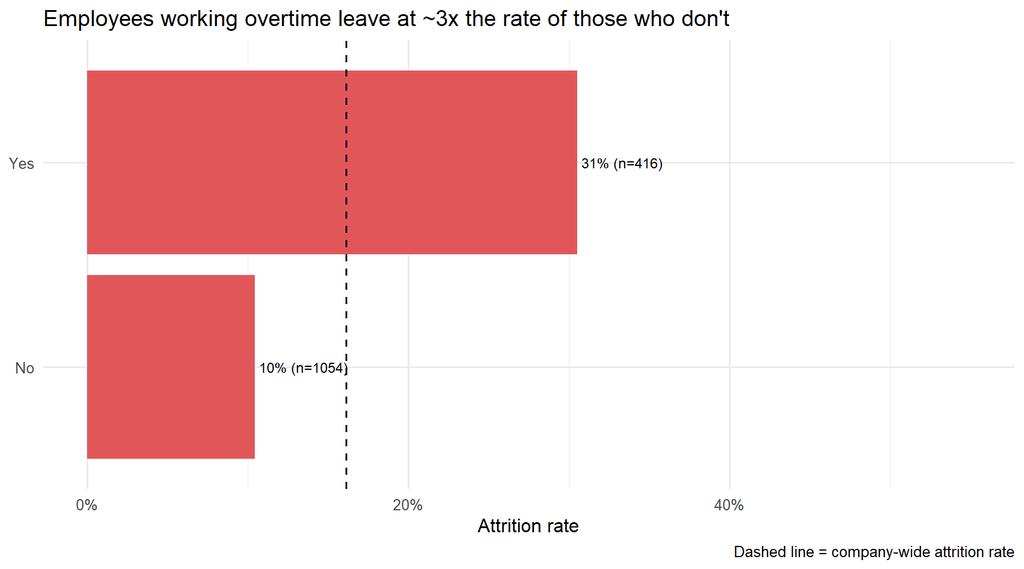

```r
plot_rate(hr, OverTime, "Employees working overtime leave at ~3x the rate of those who don't")
```

### Department and job role

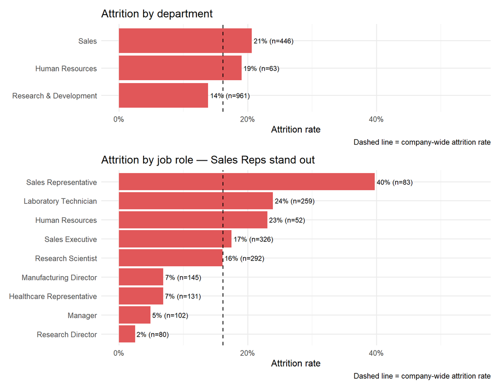

```r
p1 <- plot_rate(hr, Department, "Attrition by department")
p2 <- plot_rate(hr, JobRole, "Attrition by job role — Sales Reps stand out")
p1 / p2 + plot_layout(heights = c(1, 2))
```

### Travel, marital status, and work-life balance

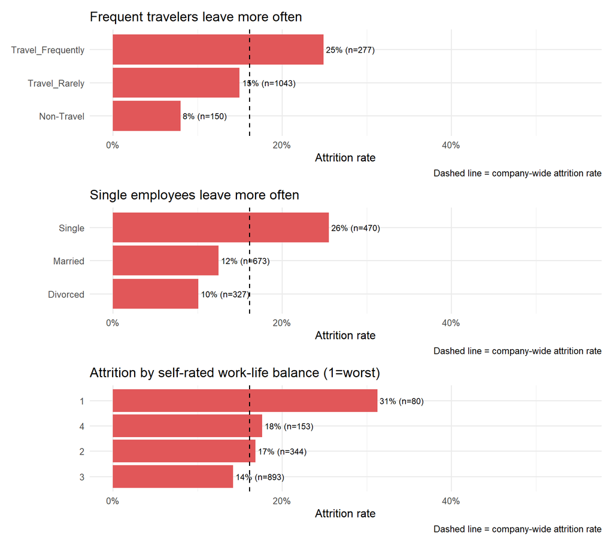

```r
p3 <- plot_rate(hr, BusinessTravel, "Frequent travelers leave more often")
p4 <- plot_rate(hr, MaritalStatus, "Single employees leave more often")
p5 <- plot_rate(hr, WorkLifeBalance, "Attrition by self-rated work-life balance (1=worst)")
p3 / p4 / p5
```

## Numeric drivers

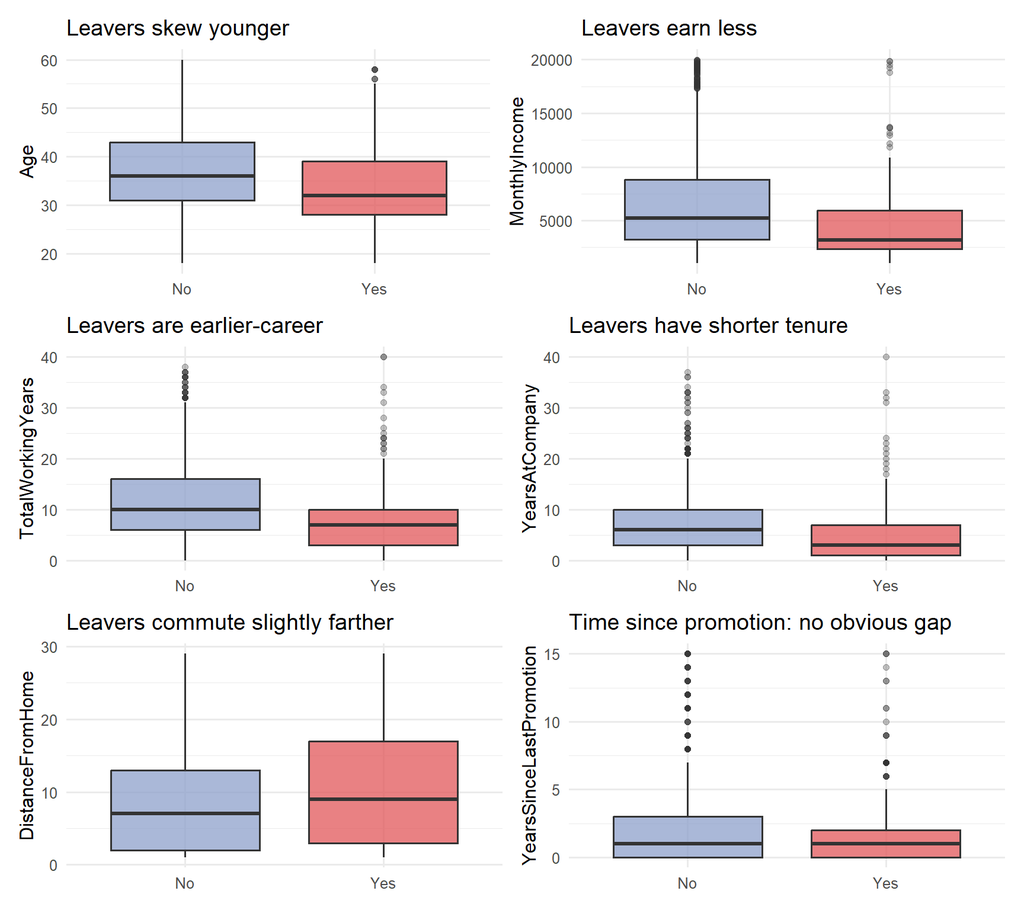

```r
num_plot <- function(col, title) {
  ggplot(hr, aes(x = Attrition, y = {{ col }}, fill = Attrition)) +
    geom_boxplot(alpha = 0.75, outlier.alpha = 0.3) +
    scale_fill_manual(values = accent, guide = "none") +
    labs(title = title, x = NULL)
}
(num_plot(Age, "Leavers skew younger") +
 num_plot(MonthlyIncome, "Leavers earn less")) /
(num_plot(TotalWorkingYears, "Leavers are earlier-career") +
 num_plot(YearsAtCompany, "Leavers have shorter tenure")) /
(num_plot(DistanceFromHome, "Leavers commute slightly farther") +
 num_plot(YearsSinceLastPromotion, "Time since promotion: no obvious gap"))
```

## Tenure × income: where the risk concentrates

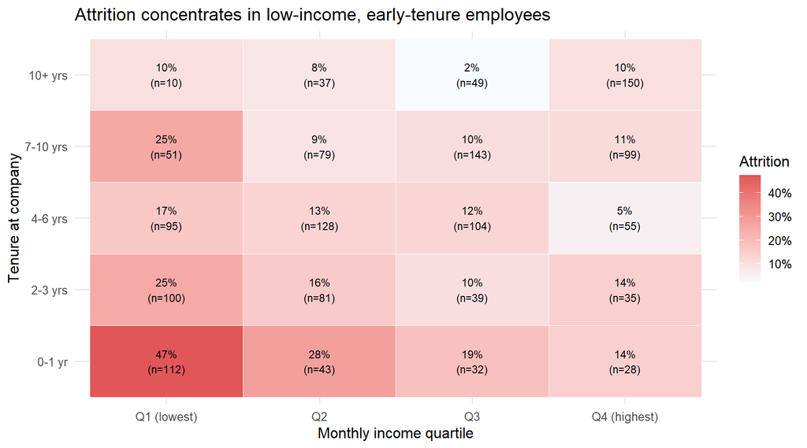

```r
banded <- hr %>%
  mutate(
    tenure_band = cut(YearsAtCompany, breaks = c(-1, 1, 3, 6, 10, 50),
                      labels = c("0-1 yr", "2-3 yrs", "4-6 yrs", "7-10 yrs", "10+ yrs")),
    income_quartile = factor(ntile(MonthlyIncome, 4),
                             labels = c("Q1 (lowest)", "Q2", "Q3", "Q4 (highest)"))
  ) %>%
  group_by(tenure_band, income_quartile) %>%
  summarise(n = n(), attrition_rate = mean(Attrition == "Yes"), .groups = "drop")

ggplot(banded, aes(income_quartile, tenure_band, fill = attrition_rate)) +
  geom_tile(color = "white") +
  geom_text(aes(label = paste0(percent(attrition_rate, 1), "\n(n=", n, ")")), size = 3) +
  scale_fill_gradient(low = "#f7fbff", high = "#e15759", labels = percent) +
  labs(title = "Attrition concentrates in low-income, early-tenure employees",
       x = "Monthly income quartile", y = "Tenure at company", fill = "Attrition")
```

## How the numeric features relate to each other

Several tenure-family variables travel together — this matters later when interpreting regression coefficients (multicollinearity).

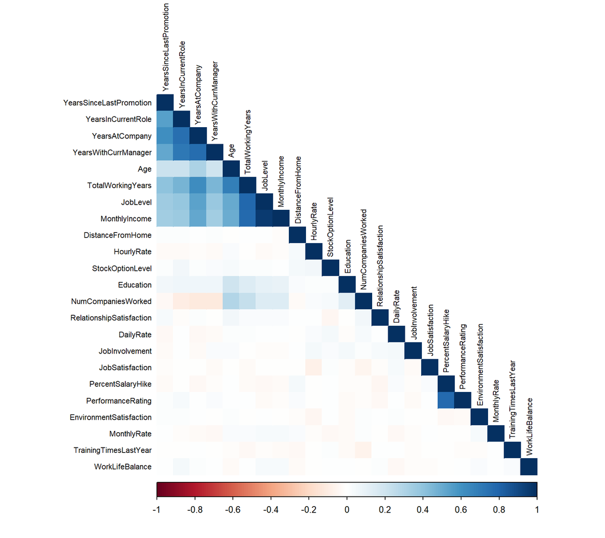

```r
num_vars <- hr %>% select(where(is.numeric), -EmployeeNumber)
corrplot(cor(num_vars), method = "color", type = "lower",
         tl.cex = 0.7, tl.col = "black", order = "hclust")
```

## What we take into Phase 2

Phase 2 puts every one of these through a formal test with multiple-comparison correction and effect sizes, so we can separate real drivers from noise — and from “statistically significant but practically trivial.”